# WHO_analysis

Minnie Jacobs

2025-09-29

## Introduction

Throughout this project, we explore data relevant to environmetal health analysis, focusing on air pollution data from the World Health Organisation. This information can be particularly relevant when identifying areas with high pollutants, trends in pollutant concentrations over time and relationships between pollutants. By exploring this data, we hope to gain an insight into some of these trends, which in a real life scenario could contribute to research in policy making to address these issues. We perform a literature review of resources for helping us analyse our data set, alongside using our own knowledge of EDA and exploring built in R packages. We will walk through how we cleaned and prepared our data, carried out EDA and found ways to visualise the trends we were able to find from this.

## Uploading and cleaning data

Since our data is sorced from the World Health Organisation, we can say with confidence that this data was reliably sourced. We begin by loading our data into R, as follows:

```r
data=read.csv("who_data.csv")
```

Next, cleaning and filtering, we removed unneccesary columns to focus on the key aspects of the dataset. It is always good to start by looking at the summary data to get an overview of our trends and identify issues.

```r
#We deleted the columns that were irrelevant.
data_new=subset(data,select=-c(X,X.1,X.2,X.3,who_ms))
summary(data_new)
```

```
##   who_region            iso3           country_name           city
##  Length:40388       Length:40388       Length:40388       Length:40388
##  Class :character   Class :character   Class :character   Class :character
##  Mode  :character   Mode  :character   Mode  :character   Mode  :character
##
##
##
##
##       year      pm10_concentration pm25_concentration no2_concentration
##  Min.   :2010   Min.   :  0.73     Min.   :  1.000    Min.   :   0.002
##  1st Qu.:2014   1st Qu.: 16.27     1st Qu.:  8.603    1st Qu.:  10.163
##  Median :2016   Median : 21.34     Median : 12.710    Median :  16.700
##  Mean   :2016   Mean   : 30.02     Mean   : 19.131    Mean   :  18.862
##  3rd Qu.:2019   3rd Qu.: 30.52     3rd Qu.: 23.000    3rd Qu.:  24.912
##  Max.   :2022   Max.   :540.00     Max.   :436.440    Max.   :3670.314
##  NA's   :293    NA's   :11716      NA's   :18658      NA's   :13454
##   pm10_tempcov     pm25_tempcov     no2_tempcov     type_of_stations
##  Min.   :  0.00   Min.   :  0.00   Min.   :  0.00   Length:40388
##  1st Qu.: 90.00   1st Qu.: 86.00   1st Qu.: 92.00   Class :character
##  Median : 96.00   Median : 96.00   Median : 96.00   Mode  :character
##  Mean   : 88.73   Mean   : 84.12   Mean   : 88.09
##  3rd Qu.: 99.00   3rd Qu.: 99.00   3rd Qu.: 98.00
##  Max.   :100.00   Max.   :100.00   Max.   :100.00
##  NA's   :17985    NA's   :23798    NA's   :16986
##    population          latitude        longitude
##  Min.   :       5   Min.   :-53.16   Min.   :-159.366
##  1st Qu.:   53006   1st Qu.: 37.14   1st Qu.:  -1.259
##  Median :  163729   Median : 43.82   Median :  10.513
##  Mean   :  757193   Mean   : 40.02   Mean   :  10.598
##  3rd Qu.:  590032   3rd Qu.: 49.16   3rd Qu.:  23.226
##  Max.   :37393129   Max.   : 69.68   Max.   : 178.450
##  NA's   :17955      NA's   :290      NA's   :290
```

As we can see we have a range of different types of data: - *Numerical:* Population counts and pollutant concentrations pm10, pm25, no2. There are something we will focus on throughout our project. -*Temporal:* Year 2010-2022. Time is an important variable when exploring long term changes in concentration of pollutants and can help illustrate trends or patterns. -*Categorical:* Country, city, station type - Spatial: Longitude and latitude coordinates (could be useful in determining whether parts of the world have a trend in a higher concentration of pollutants.)

There is also a very large range for variables such as no2 concentration. First we consider reasons for these spikes, they could be measurement error or extreme pollution events as a consequence of natural disasters.A good approach to deal with the large ranges is to scale the data, for example, using a log transformation, or we could identify some as outliers and cap the values. We also notice a large number of NA values for each category. We could remove missing data and cap values to avoid extreme outliers, but we might not want to dismiss all the missing data as we could accidentally introduce bias.

## Dealing with missing data

We explore to see if there is a trend in missing data, e.g. one country has more missing data than another, to do so we identify *How many NA’s in pm10, pm25 and no2 for each country?* This way we can decide which countries to focus on for our analysis.

```r
library(dplyr)
data_new %>%
  group_by(country_name) %>%
  summarise(
    na_count = sum(is.na(pm10_concentration)),
    count= n(),
    proportion=na_count/count) %>%
  filter(proportion< 0.3 & count>500)
```

```
## # A tibble: 12 × 4
##    country_name  na_count count proportion
##    <chr>            <int> <int>      <dbl>
##  1 "Austria"          225  1207     0.186
##  2 "Belgium"          165   560     0.295
##  3 "Czechia"           49   956     0.0513
##  4 "France"           542  3132     0.173
##  5 "Germany"          559  3266     0.171
##  6 "India"             37  1301     0.0284
##  7 "Italy"            523  4035     0.130
##  8 "Poland"           144  1704     0.0845
##  9 "Romania"          163   822     0.198
## 10 "Spain"            552  3343     0.165
## 11 "Switzerland"       80  1005     0.0796
## 12 "T?\xbarkiye"       53  1039     0.0510
```

```r
library(dplyr)
data_new %>%
  group_by(country_name) %>%
  summarise(
    na_count = sum(is.na(pm25_concentration)),
    count= n(),
    proportion=na_count/count) %>%
  filter(proportion< 0.3 & count>100)
```

```
## # A tibble: 8 × 4
##   country_name             na_count count proportion
##   <chr>                       <int> <int>      <dbl>
## 1 Australia                      66   221   0.299
## 2 Canada                         77  1169   0.0659
## 3 Chile                          25   210   0.119
## 4 China                           1  3882   0.000258
## 5 Norway                         55   250   0.22
## 6 Slovakia                       31   303   0.102
## 7 South Africa                   46   157   0.293
## 8 United States of America      532  3888   0.137
```

```r
library(dplyr)
data_new %>%
  group_by(country_name) %>%
  summarise(
    na_count = sum(is.na(no2_concentration)),
    count= n(),
    proportion=na_count/count) %>%
  filter(proportion< 0.3 & count>500)
```

```
## # A tibble: 10 × 4
##    country_name                                        na_count count proportion
##    <chr>                                                  <int> <int>      <dbl>
##  1 Austria                                                   77  1207     0.0638
##  2 Belgium                                                   60   560     0.107
##  3 France                                                   454  3132     0.145
##  4 Germany                                                  155  3266     0.0475
##  5 Israel                                                   148   522     0.284
##  6 Italy                                                    183  4035     0.0454
##  7 Spain                                                    280  3343     0.0838
##  8 Sweden                                                   100   601     0.166
##  9 Switzerland                                               48  1005     0.0478
## 10 United Kingdom of Great Britain and Northern Irela…       43   881     0.0488
```

```r
library(dplyr)
data_new %>%
  group_by(city) %>%
  summarise(
    na_count = sum(is.na(pm10_concentration)),
    count    = n(),
    proportion=na_count/count) %>%
  filter(proportion < 0.85)
```

```
## # A tibble: 5,015 × 4
##    city                  na_count count proportion
##    <chr>                    <int> <int>      <dbl>
##  1 ???/KOR                      0     6          0
##  2 A Coruna/ESP                 0     9          0
##  3 Aachen/DEU                   0    10          0
##  4 Aadorf/CHE                   0     7          0
##  5 Aalen/DEU                    0    10          0
##  6 Aalesund/NOR                 0     1          0
##  7 Aarau/CHE                    0     4          0
##  8 Aarhus/DNK                   0     1          0
##  9 Aarschot/BEL                 0     9          0
## 10 Abanto Y Ciervana/ESP        0     1          0
## # ℹ 5,005 more rows
```

# Creating subsets based on missing data

```r
pm10_top_10= data_new %>%
  filter(country_name %in%
c("Austria","Belgium", "Bulgaria", "Czechia","France","Germany","Italy","Netherlands (Kingdom of the)", "Poland","Switzerland"))
pm25_top_10= data_new %>%
  filter(country_name %in% c("Australia","Canada","Chile","China","Norway","Slovakia","South Africa","United States of America"))
no2_top_10= data_new %>%
  filter(country_name %in%
c("Austria","Belgium","France","Germany","Israel","Italy","Spain","Sweden","Switzerland","United Kingdom of Great Britain and Northern Ireland"))
```

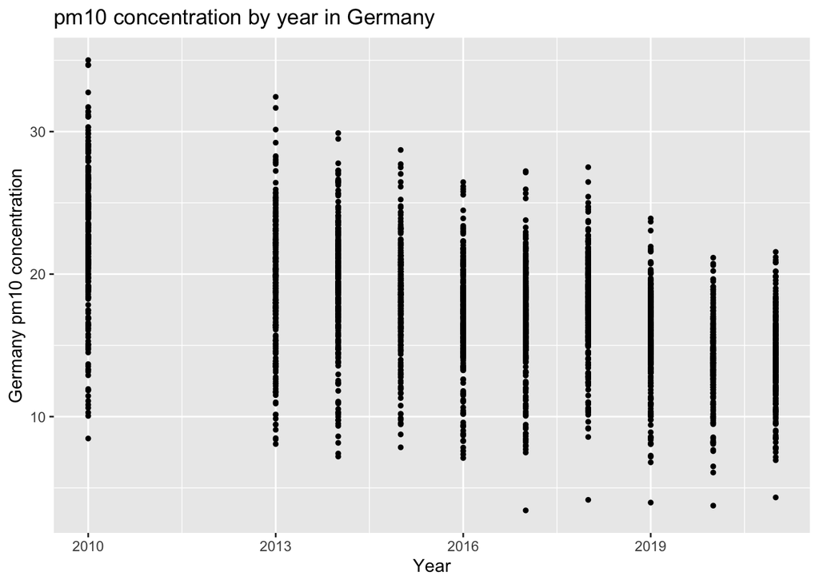

```r
library(ggplot2)
library(dplyr)
germany_data=data_new %>%
  filter(country_name == "Germany")

ggplot(germany_data, aes(x = year, y = pm10_concentration)) +
  geom_point(color ="black", size = 1) +
  labs(
    title = "pm10 concentration by year in Germany",x = "Year",y = "Germany pm10 concentration")
```

Evidently there is a clear trend in Germany’s pm10 concentration over time, if we were to explore this further we could fit a line of best fit to identify at what rate the particle concentration is decreasing over time. Using our subsets we created, we can create time series plots for all of them simultaneously, using facet_wrap.